# Reproducible Research: Peer Assessment 1

Note: Full project instructions were copied in this file for documentation and ease of completing the assignment. Throughout the report, all code generating output is included.

## Loading and preprocessing the data

Required packages (from the wonderful Hadleyverse)

```r
library(readr)
library(dplyr)
library(knitr)
library(ggplot2)
```

1. Load the data
2. Process/transform the data into a format suitable for analysis

```r
Data <- tbl_df(read_csv("activity.zip",
                        skip=1,
                        col_names=c("Steps","Date","Interval"),
                        col_types=list(col_integer(),col_date(),col_integer())))

#verifed data was loaded as expected and reviewed its format
#no further processing needed at this point
str(Data);summary(Data);Data
```

```
## Classes 'tbl_df', 'tbl' and 'data.frame':    17568 obs. of  3 variables:
##  $ Steps   : int  NA NA NA NA NA NA NA NA NA NA ...
##  $ Date    : Date, format: "2012-10-01" "2012-10-01" ...
##  $ Interval: int  0 5 10 15 20 25 30 35 40 45 ...
```

```
##      Steps             Date               Interval
##  Min.   :  0.00   Min.   :2012-10-01   Min.   :   0.0
##  1st Qu.:  0.00   1st Qu.:2012-10-16   1st Qu.: 588.8
##  Median :  0.00   Median :2012-10-31   Median :1177.5
##  Mean   : 37.38   Mean   :2012-10-31   Mean   :1177.5
##  3rd Qu.: 12.00   3rd Qu.:2012-11-15   3rd Qu.:1766.2
##  Max.   :806.00   Max.   :2012-11-30   Max.   :2355.0
##  NA's   :2304
```

```
## Source: local data frame [17,568 x 3]
##
##    Steps       Date Interval
## 1     NA 2012-10-01        0
## 2     NA 2012-10-01        5
## 3     NA 2012-10-01       10
## 4     NA 2012-10-01       15
## 5     NA 2012-10-01       20
## 6     NA 2012-10-01       25
## 7     NA 2012-10-01       30
## 8     NA 2012-10-01       35
## 9     NA 2012-10-01       40
## 10    NA 2012-10-01       45
## ..   ...        ...      ...
```

## What is mean total number of steps taken per day?

For this part of the assignment, ignore the missing values in the dataset

1. Calculate the total number of steps taken per day

```r
DaySteps <- Data %>%
                filter(!is.na(Steps)) %>%
                group_by(Date) %>%
                summarize(TotalSteps=sum(Steps))
kable(DaySteps)
```

| Date | TotalSteps |
| --- | --- |
| 2012-10-02 | 126 |
| 2012-10-03 | 11352 |
| 2012-10-04 | 12116 |
| 2012-10-05 | 13294 |
| 2012-10-06 | 15420 |
| 2012-10-07 | 11015 |
| 2012-10-09 | 12811 |
| 2012-10-10 | 9900 |
| 2012-10-11 | 10304 |
| 2012-10-12 | 17382 |
| 2012-10-13 | 12426 |
| 2012-10-14 | 15098 |
| 2012-10-15 | 10139 |
| 2012-10-16 | 15084 |
| 2012-10-17 | 13452 |
| 2012-10-18 | 10056 |
| 2012-10-19 | 11829 |
| 2012-10-20 | 10395 |
| 2012-10-21 | 8821 |
| 2012-10-22 | 13460 |
| 2012-10-23 | 8918 |
| 2012-10-24 | 8355 |
| 2012-10-25 | 2492 |
| 2012-10-26 | 6778 |
| 2012-10-27 | 10119 |
| 2012-10-28 | 11458 |
| 2012-10-29 | 5018 |
| 2012-10-30 | 9819 |
| 2012-10-31 | 15414 |
| 2012-11-02 | 10600 |
| 2012-11-03 | 10571 |
| 2012-11-05 | 10439 |
| 2012-11-06 | 8334 |
| 2012-11-07 | 12883 |
| 2012-11-08 | 3219 |
| 2012-11-11 | 12608 |
| 2012-11-12 | 10765 |
| 2012-11-13 | 7336 |
| 2012-11-15 | 41 |
| 2012-11-16 | 5441 |
| 2012-11-17 | 14339 |
| 2012-11-18 | 15110 |
| 2012-11-19 | 8841 |
| 2012-11-20 | 4472 |
| 2012-11-21 | 12787 |
| 2012-11-22 | 20427 |
| 2012-11-23 | 21194 |
| 2012-11-24 | 14478 |
| 2012-11-25 | 11834 |
| 2012-11-26 | 11162 |
| 2012-11-27 | 13646 |
| 2012-11-28 | 10183 |
| 2012-11-29 | 7047 |

2. Make a histogram of the total number of steps taken each day

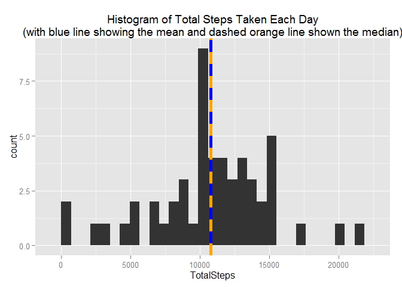

```r
StepHistogram <- ggplot(DaySteps, aes(x=TotalSteps)) +
                    geom_histogram() +
                    geom_vline(aes(xintercept=mean(TotalSteps))
                               ,color="blue"
                               ,size=2) +
                    geom_vline(aes(xintercept=median(TotalSteps))
                               ,color="orange"
                               ,size=2
                               ,linetype="dashed") +
                    ggtitle("Histogram of Total Steps Taken Each Day
(with blue line showing the mean and dashed orange line shown the median)")
StepHistogram
```

3. Calculate and report the mean and median of the total number of steps taken per day

```r
mean(DaySteps$TotalSteps);median(DaySteps$TotalSteps)
```

```
## [1] 10766.19
```

```
## [1] 10765
```

## What is the average daily activity pattern?

1. Make a time series plot (i.e., type=“l”) of the 5-minute interval (x-axis) and the average number of steps taken, averaged across all days (y-axis)

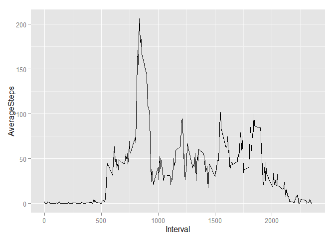

```r
MeanSteps <- Data %>%
                filter(!is.na(Steps)) %>%
                group_by(Interval) %>%
                summarize(AverageSteps=mean(Steps))
qplot(Interval,AverageSteps,data=MeanSteps,geom="line")
```

2. Which 5-minute interval, on average across all the days in the dataset, contains the maximum number of steps?

```r
kable(MeanSteps %>%
        arrange(desc(AverageSteps),Interval) %>%
        top_n(1))
```

| Interval | AverageSteps |
| --- | --- |
| 835 | 206.1698 |

## Imputing missing values

Note that there are a number of days/intervals where there are missing values (coded as NA). The presence of missing days may introduce bias into some calculations or summaries of the data.

1. Calculate and report the total number of missing values in the dataset (i.e. the total number of rows with NAs)

```r
MissingByDate <- Data %>%
                    filter(is.na(Steps)) %>%
                    group_by(Date) %>%
                    summarize(MissingCount=n())
#288 missing intervals equals one day (288*5=1440; 1440/60=24)
#8 days have all their Step values missing
kable(MissingByDate)
```

| Date | MissingCount |
| --- | --- |
| 2012-10-01 | 288 |
| 2012-10-08 | 288 |
| 2012-11-01 | 288 |
| 2012-11-04 | 288 |
| 2012-11-09 | 288 |
| 2012-11-10 | 288 |
| 2012-11-14 | 288 |
| 2012-11-30 | 288 |

```r
#total number of rows with NAs
sum(MissingByDate$MissingCount)
```

```
## [1] 2304
```

2. Devise a strategy for filling in all of the missing values in the dataset. The strategy does not need to be sophisticated. For example, you could use the mean/median for that day, or the mean for that 5-minute interval, etc.
3. Create a new dataset that is equal to the original dataset but with the missing data filled in.

```r
#For the imputation strategy, decided to use the mean for the 5-minute interval
#Mainly chosen because entire days were missing values
ImputedData <- inner_join(Data,MeanSteps,by="Interval") %>%
                mutate(ImputedSteps=ifelse(is.na(Steps),AverageSteps,Steps))
kable(ImputedData[c(1:5,646:651),]) #sample of new dataset
```

| Steps | Date | Interval | AverageSteps | ImputedSteps |
| --- | --- | --- | --- | --- |
| NA | 2012-10-01 | 0 | 1.7169811 | 1.7169811 |
| NA | 2012-10-01 | 5 | 0.3396226 | 0.3396226 |
| NA | 2012-10-01 | 10 | 0.1320755 | 0.1320755 |
| NA | 2012-10-01 | 15 | 0.1509434 | 0.1509434 |
| NA | 2012-10-01 | 20 | 0.0754717 | 0.0754717 |
| 0 | 2012-10-03 | 545 | 18.3396226 | 0.0000000 |
| 90 | 2012-10-03 | 550 | 39.4528302 | 90.0000000 |
| 411 | 2012-10-03 | 555 | 44.4905660 | 411.0000000 |
| 413 | 2012-10-03 | 600 | 31.4905660 | 413.0000000 |
| 415 | 2012-10-03 | 605 | 49.2641509 | 415.0000000 |
| 519 | 2012-10-03 | 610 | 53.7735849 | 519.0000000 |

4. Make a histogram of the total number of steps taken each day. Calculate and report the mean and median total number of steps taken per day. Do these values differ from the estimates from the first part of the assignment? What is the impact of imputing missing data on the estimates of the total daily number of steps?

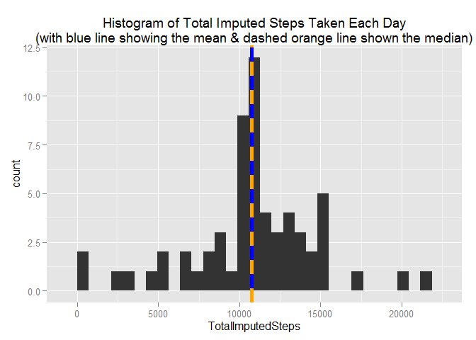

```r
DayStepsImp <- ImputedData %>%
                        group_by(Date) %>%
                        summarize(TotalImputedSteps=sum(ImputedSteps))

StepHistogramImp <- ggplot(DayStepsImp, aes(x=TotalImputedSteps)) +
                        geom_histogram() +
                        geom_vline(aes(xintercept=mean(TotalImputedSteps))
                                   ,color="blue"
                                   ,size=2) +
                        geom_vline(aes(xintercept=median(TotalImputedSteps))
                                   ,color="orange"
                                   ,size=2
                                   ,linetype="dashed") +
                        ggtitle("Histogram of Total Imputed Steps Taken Each Day
(with blue line showing the mean & dashed orange line shown the median)")
StepHistogramImp
```

```r
#The imputed missing values have no impact on the mean
#The medians do differ, with the imputed being slighly larger
OrigDataStats <- data.frame(DataType="Original"
                            ,MeanSteps=mean(DaySteps$TotalSteps)
                            ,MedianSteps=median(DaySteps$TotalSteps))
ImpDataStats <- data.frame(DataType="Imputed"
                            ,MeanSteps=mean(DayStepsImp$TotalImputedSteps)
                            ,MedianSteps=median(DayStepsImp$TotalImputedSteps))
kable(bind_rows(OrigDataStats,ImpDataStats))
```

| DataType | MeanSteps | MedianSteps |
| --- | --- | --- |
| Original | 10766.19 | 10765.00 |
| Imputed | 10766.19 | 10766.19 |

## Are there differences in activity patterns between weekdays and weekends?

For this part the weekdays() function may be of some help here. Use the dataset with the filled-in missing values for this part.

1. Create a new factor variable in the dataset with two levels - “weekday” and “weekend” indicating whether a given date is a weekday or weekend day.

```r
ImputedData <- ImputedData %>%
                mutate(DayType=as.factor(ifelse(weekdays(ImputedData$Date)
                                                %in% c("Sunday","Saturday"),
                                                "Weekend","Weekday")))
kable(ImputedData[c(1,2001),c("Date","DayType")]) #sample to see new variable
```

| Date | DayType |
| --- | --- |
| 2012-10-01 | Weekday |
| 2012-10-07 | Weekend |

2. Make a panel plot containing a time series plot (i.e. type = “l”) of the 5-minute interval (x-axis) and the average number of steps taken, averaged across all weekday days or weekend days (y-axis). See the README file in the GitHub repository to see an example of what this plot should look like using simulated data.

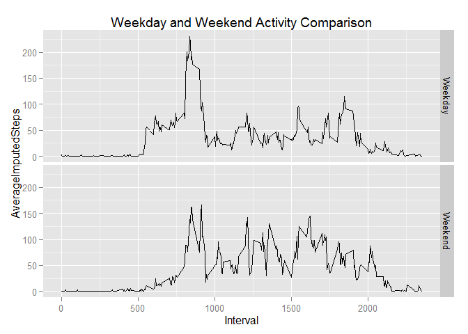

```r
MeanStepsImp <- ImputedData %>%
                    group_by(Interval,DayType) %>%
                    summarize(AverageImputedSteps=mean(ImputedSteps))
plot <- ggplot(MeanStepsImp,aes(Interval,AverageImputedSteps)) +
            geom_line() +
            facet_grid(DayType~.) +
            ggtitle("Weekday and Weekend Activity Comparison")
plot
```